# 6306_Project1_Zwei Group

Elisabet Zidow, Jonathan Franks, Shanqing Gu

2/18/2018

## Q1: How many breweries are present in each state?

```r
breweries <- read.csv("/Users/shanqinggu/Desktop/6306_Project_01/Breweries.csv", header=TRUE)
str(breweries)
```

```
## 'data.frame':    558 obs. of  4 variables:
##  $ Brew_ID: int  1 2 3 4 5 6 7 8 9 10 ...
##  $ Name   : Factor w/ 551 levels "10 Barrel Brewing Company",..: 355 12 266 319 201 136 227 477 59 491 ...
##  $ City   : Factor w/ 384 levels "Abingdon","Abita Springs",..: 228 200 122 299 300 62 91 48 152 136 ...
##  $ State  : Factor w/ 51 levels " AK"," AL"," AR",..: 24 18 20 5 5 41 6 23 23 23 ...
```

```r
head(breweries)
```

```
##   Brew_ID                      Name          City State
## 1       1        NorthGate Brewing    Minneapolis    MN
## 2       2 Against the Grain Brewery    Louisville    KY
## 3       3  Jack's Abby Craft Lagers    Framingham    MA
## 4       4 Mike Hess Brewing Company     San Diego    CA
## 5       5   Fort Point Beer Company San Francisco    CA
## 6       6     COAST Brewing Company    Charleston    SC
```

```r
summary(breweries)
```

```
##     Brew_ID                           Name           City
##  Min.   :  1.0   Blackrocks Brewery     :  2   Portland: 17
##  1st Qu.:140.2   Blue Mountain Brewery  :  2   Boulder :  9
##  Median :279.5   Lucette Brewing Company:  2   Chicago :  9
##  Mean   :279.5   Oskar Blues Brewery    :  2   Seattle :  9
##  3rd Qu.:418.8   Otter Creek Brewing    :  2   Austin  :  8
##  Max.   :558.0   Sly Fox Brewing Company:  2   Denver  :  8
##                  (Other)                :546   (Other) :498
##      State
##   CO    : 47
##   CA    : 39
##   MI    : 32
##   OR    : 29
##   TX    : 28
##   PA    : 25
##  (Other):358
```

```r
library("plyr")

breweries.count <- as.data.frame(table(breweries$State))
head(breweries.count)
```

```
##   Var1 Freq
## 1   AK    7
## 2   AL    3
## 3   AR    2
## 4   AZ   11
## 5   CA   39
## 6   CO   47
```

```r
breweries.order <- breweries.count[order(breweries.count$Freq, decreasing=TRUE),]
head(breweries.order)
```

```
##    Var1 Freq
## 6    CO   47
## 5    CA   39
## 23   MI   32
## 38   OR   29
## 44   TX   28
## 39   PA   25
```

```r
breweries.order$Var1 <- factor(breweries.order$Var1, levels = breweries.order$Var1[order(breweries.order$Freq)])
breweries.order$Var1
```

```
##  [1]  CO  CA  MI  OR  TX  PA  MA  WA  IN  WI  NC  IL  NY  VA  FL  OH  MN
## [18]  AZ  VT  ME  MO  MT  CT  AK  GA  MD  OK  IA  ID  LA  NE  RI  HI  KY
## [35]  NM  SC  UT  WY  AL  KS  NH  NJ  TN  AR  DE  MS  NV  DC  ND  SD  WV
## 51 Levels:  DC  ND  SD  WV  AR  DE  MS  NV  AL  KS  NH  NJ  TN  HI ...  CO
```

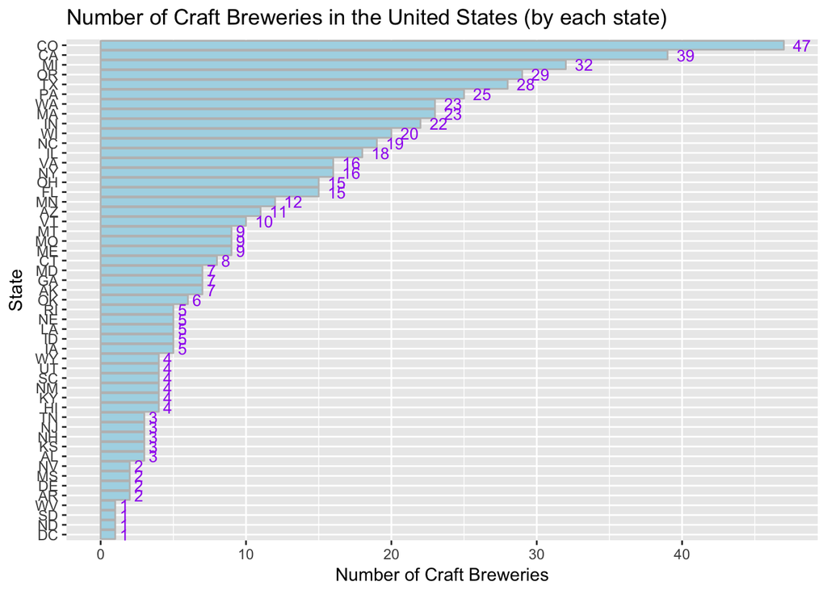

```r
library(ggplot2)

freq.plot <- ggplot(data=breweries.order, aes(x=Var1, y=Freq))+
  geom_bar(stat="identity", color="grey", fill="light blue")+
  geom_text(aes(label=Freq), hjust=-0.5, color="purple", position = position_dodge(0.9), size=3.5)+
  scale_fill_brewer(palette="Paired")+
  labs(title="Number of Craft Breweries in the United States (by each state)", x="State", y="Number of Craft Breweries")

freq.plot + coord_flip()
```

# Q2: What are the median ABV and IBU values for each state?

For this question, first we need to merge beer data with breweries data by Brew_ID. Use the firt and last six observations to check the merged file.

```r
beers <- read.csv("/Users/shanqinggu/Desktop/6306_Project_01/Beers.csv", header=TRUE)
str(beers)
```

```
## 'data.frame':    2410 obs. of  7 variables:
##  $ Name      : Factor w/ 2305 levels "#001 Golden Amber Lager",..: 1638 577 1704 1842 1819 268 1160 758 1093 486 ...
##  $ Beer_ID   : int  1436 2265 2264 2263 2262 2261 2260 2259 2258 2131 ...
##  $ ABV       : num  0.05 0.066 0.071 0.09 0.075 0.077 0.045 0.065 0.055 0.086 ...
##  $ IBU       : int  NA NA NA NA NA NA NA NA NA NA ...
##  $ Brewery_id: int  409 178 178 178 178 178 178 178 178 178 ...
##  $ Style     : Factor w/ 100 levels "","Abbey Single Ale",..: 19 18 16 12 16 80 18 22 18 12 ...
##  $ Ounces    : num  12 12 12 12 12 12 12 12 12 12 ...
```

```r
head(beers)
```

```
##                  Name Beer_ID   ABV IBU Brewery_id
## 1            Pub Beer    1436 0.050  NA        409
## 2         Devil's Cup    2265 0.066  NA        178
## 3 Rise of the Phoenix    2264 0.071  NA        178
## 4            Sinister    2263 0.090  NA        178
## 5       Sex and Candy    2262 0.075  NA        178
## 6        Black Exodus    2261 0.077  NA        178
##                            Style Ounces
## 1            American Pale Lager     12
## 2        American Pale Ale (APA)     12
## 3                   American IPA     12
## 4 American Double / Imperial IPA     12
## 5                   American IPA     12
## 6                  Oatmeal Stout     12
```

```r
dim(beers)
```

```
## [1] 2410    7
```

```r
summary(beers)
```

```
##                      Name         Beer_ID            ABV
##  Nonstop Hef Hop       :  12   Min.   :   1.0   Min.   :0.00100
##  Dale's Pale Ale       :   6   1st Qu.: 808.2   1st Qu.:0.05000
##  Oktoberfest           :   6   Median :1453.5   Median :0.05600
##  Longboard Island Lager:   4   Mean   :1431.1   Mean   :0.05977
##  1327 Pod's ESB        :   3   3rd Qu.:2075.8   3rd Qu.:0.06700
##  Boston Lager          :   3   Max.   :2692.0   Max.   :0.12800
##  (Other)               :2376                    NA's   :62
##       IBU           Brewery_id                               Style
##  Min.   :  4.00   Min.   :  1.0   American IPA                  : 424
##  1st Qu.: 21.00   1st Qu.: 94.0   American Pale Ale (APA)       : 245
##  Median : 35.00   Median :206.0   American Amber / Red Ale      : 133
##  Mean   : 42.71   Mean   :232.7   American Blonde Ale           : 108
##  3rd Qu.: 64.00   3rd Qu.:367.0   American Double / Imperial IPA: 105
##  Max.   :138.00   Max.   :558.0   American Pale Wheat Ale       :  97
##  NA's   :1005                     (Other)                       :1298
##      Ounces
##  Min.   : 8.40
##  1st Qu.:12.00
##  Median :12.00
##  Mean   :13.59
##  3rd Qu.:16.00
##  Max.   :32.00
##
```

```r
colnames(beers)[5] <- "Brew_ID"
head(beers)
```

```
##                  Name Beer_ID   ABV IBU Brew_ID
## 1            Pub Beer    1436 0.050  NA     409
## 2         Devil's Cup    2265 0.066  NA     178
## 3 Rise of the Phoenix    2264 0.071  NA     178
## 4            Sinister    2263 0.090  NA     178
## 5       Sex and Candy    2262 0.075  NA     178
## 6        Black Exodus    2261 0.077  NA     178
##                            Style Ounces
## 1            American Pale Lager     12
## 2        American Pale Ale (APA)     12
## 3                   American IPA     12
## 4 American Double / Imperial IPA     12
## 5                   American IPA     12
## 6                  Oatmeal Stout     12
```

```r
beer.merge <- merge.data.frame(beers, breweries, by="Brew_ID", all=FALSE)
head(beer.merge, 6)
```

```
##   Brew_ID        Name.x Beer_ID   ABV IBU
## 1       1  Get Together    2692 0.045  50
## 2       1 Maggie's Leap    2691 0.049  26
## 3       1    Wall's End    2690 0.048  19
## 4       1       Pumpion    2689 0.060  38
## 5       1    Stronghold    2688 0.060  25
## 6       1   Parapet ESB    2687 0.056  47
##                                 Style Ounces             Name.y
## 1                        American IPA     16 NorthGate Brewing
## 2                  Milk / Sweet Stout     16 NorthGate Brewing
## 3                   English Brown Ale     16 NorthGate Brewing
## 4                         Pumpkin Ale     16 NorthGate Brewing
## 5                     American Porter     16 NorthGate Brewing
## 6 Extra Special / Strong Bitter (ESB)     16 NorthGate Brewing
##          City State
## 1 Minneapolis    MN
## 2 Minneapolis    MN
## 3 Minneapolis    MN
## 4 Minneapolis    MN
## 5 Minneapolis    MN
## 6 Minneapolis    MN
```

```r
tail(beer.merge, 6)
```

```
##      Brew_ID                    Name.x Beer_ID   ABV IBU
## 2405     556             Pilsner Ukiah      98 0.055  NA
## 2406     557  Heinnieweisse Weissebier      52 0.049  NA
## 2407     557           Snapperhead IPA      51 0.068  NA
## 2408     557         Moo Thunder Stout      50 0.049  NA
## 2409     557         Porkslap Pale Ale      49 0.043  NA
## 2410     558 Urban Wilderness Pale Ale      30 0.049  NA
##                        Style Ounces                        Name.y
## 2405         German Pilsener     12         Ukiah Brewing Company
## 2406              Hefeweizen     12       Butternuts Beer and Ale
## 2407            American IPA     12       Butternuts Beer and Ale
## 2408      Milk / Sweet Stout     12       Butternuts Beer and Ale
## 2409 American Pale Ale (APA)     12       Butternuts Beer and Ale
## 2410        English Pale Ale     12 Sleeping Lady Brewing Company
##               City State
## 2405         Ukiah    CA
## 2406 Garrattsville    NY
## 2407 Garrattsville    NY
## 2408 Garrattsville    NY
## 2409 Garrattsville    NY
## 2410     Anchorage    AK
```

```r
dim(beer.merge)
```

```
## [1] 2410   10
```

Secondly, we need to report the numbers of NA’s in each column. There are 62 NAs in the ABV column, while 1005 in the IBU column.

```r
colSums(is.na(beer.merge))
```

```
## Brew_ID  Name.x Beer_ID     ABV     IBU   Style  Ounces  Name.y    City
##       0       0       0      62    1005       0       0       0       0
##   State
##       0
```

lastly, we compute and plot the median ABV and IBU for each state to compare by the SummaryBy statement in doBy libarary.

```r
library(doBy)

bar.median <- summaryBy(ABV+IBU~State,data=beer.merge, FUN=median, na.rm=TRUE)
dim(bar.median)
```

```
## [1] 51  3
```

```r
bar.median
```

```
##    State ABV.median IBU.median
## 1     AK     0.0560       46.0
## 2     AL     0.0600       43.0
## 3     AR     0.0520       39.0
## 4     AZ     0.0550       20.5
## 5     CA     0.0580       42.0
## 6     CO     0.0605       40.0
## 7     CT     0.0600       29.0
## 8     DC     0.0625       47.5
## 9     DE     0.0550       52.0
## 10    FL     0.0570       55.0
## 11    GA     0.0550       55.0
## 12    HI     0.0540       22.5
## 13    IA     0.0555       26.0
## 14    ID     0.0565       39.0
```

[output cut: 37 more lines]

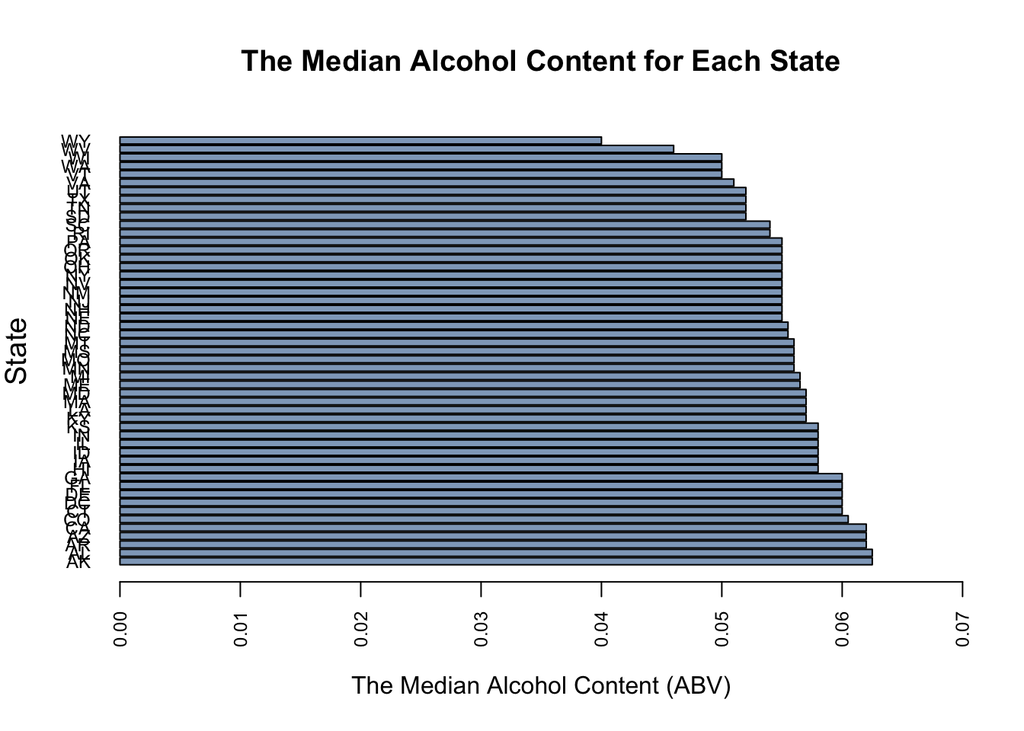

```r
bar.median.ABV <- bar.median[order(bar.median$ABV.median, decreasing=TRUE),]
bar.median.IBU <- bar.median[order(bar.median$IBU.median, decreasing=TRUE),]

barplot(bar.median.ABV$ABV.median, las=2, horiz=TRUE,
        main = "The Median Alcohol Content for Each State",
        xlab = "The Median Alcohol Content (ABV)",
        col=rgb(0.2,0.4,0.6,0.6),
        names.arg=(bar.median$State), font=1,
        cex.axis=0.75, cex.names =0.75,
        xlim = c( 0, 0.07))
title(ylab="State", mgp=c(3,1,0), cex.lab=1.2)
```

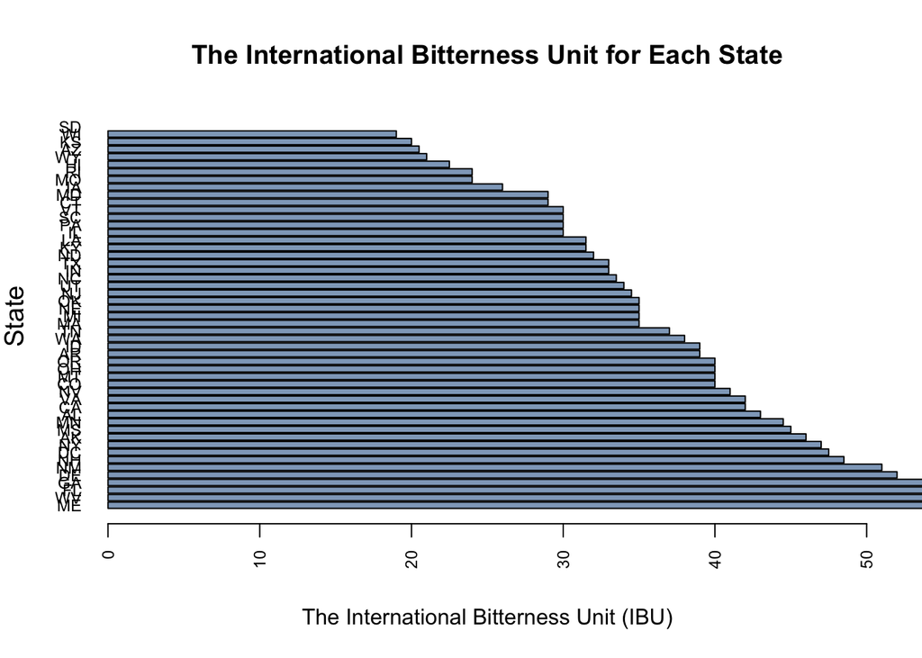

```r
barplot(bar.median.IBU$IBU.median, las=2, horiz=TRUE,
        main = "The International Bitterness Unit for Each State",
        xlab = "The International Bitterness Unit (IBU)",
        col=rgb(0.2,0.4,0.6,0.6),
        names.arg=(bar.median.IBU$State), font=1,
        cex.axis=0.75, cex.names =0.75,
        xlim = c( 0, 50))
title(ylab="State", mgp=c(3,1,0), cex.lab=1.2)
```

# Q3 Which state has the maximum ABV or IBU beer?

Use which.max function to find the state to have the maximum ABU and IBU beer. As shown below, Colorado (CO) has the highese ABU beer and Oregon has the hight IBU beer.

```r
ABV.Max <- beer.merge[which.max(beer.merge$ABV),]
ABV.Max
```

```
##     Brew_ID                                               Name.x Beer_ID
## 375      52 Lee Hill Series Vol. 5 - Belgian Style Quadrupel Ale    2565
##       ABV IBU            Style Ounces                  Name.y    City
## 375 0.128  NA Quadrupel (Quad)   19.2 Upslope Brewing Company Boulder
##     State
## 375    CO
```

```r
IBU.Max <- beer.merge[which.max(beer.merge$IBU),]
IBU.Max
```

```
##      Brew_ID                    Name.x Beer_ID   ABV IBU
## 1857     375 Bitter Bitch Imperial IPA     980 0.082 138
##                               Style Ounces                  Name.y    City
## 1857 American Double / Imperial IPA     12 Astoria Brewing Company Astoria
##      State
## 1857    OR
```

From the summary statistics for the ABV variable, we can check the deta details: n, mean, sd, median, min, max, range and so on.

```r
library(psych)
describe(beer.merge$ABV)
```

```
##    vars    n mean   sd median trimmed  mad min  max range skew kurtosis se
## X1    1 2348 0.06 0.01   0.06    0.06 0.01   0 0.13  0.13 0.96     1.14  0
```

# Q4 Is there an relationship between the ABV and IBU?

The scatterplot and regression line support a strong positive correlation between ABV and IBU.

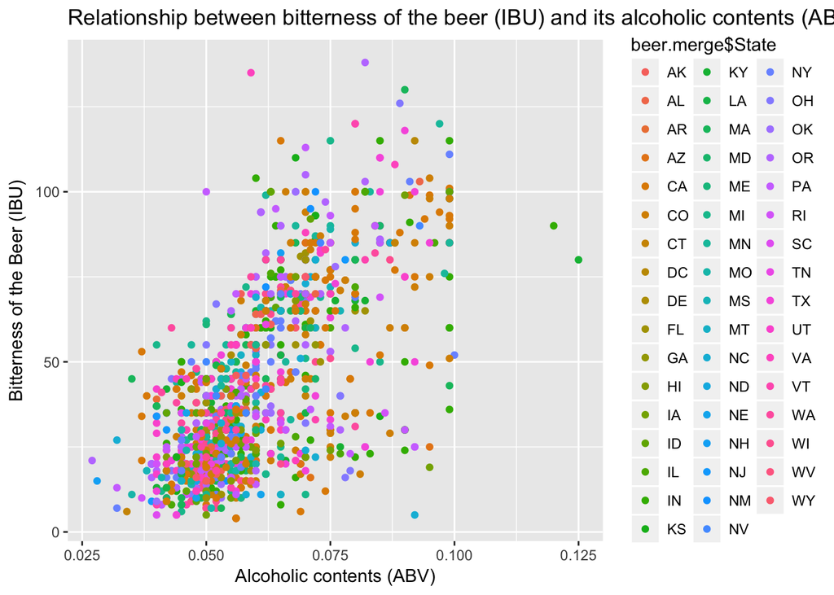

```r
library(ggplot2)
beer.merge <- na.omit(beer.merge)
ggplot(data = beer.merge, na.rm=TRUE) +
  geom_point(mapping = aes(x = ABV, y = IBU, color = beer.merge$State))+
  labs(title="Relationship between bitterness of the beer (IBU) and its alcoholic contents (ABV) with scatter plot",
      x="Alcoholic contents (ABV)", y="Bitterness of the Beer (IBU)")
```

```r
lm.fit <- lm(IBU ~ ABV, data = beer.merge)
summary (lm.fit)
```

```
##
## Call:
## lm(formula = IBU ~ ABV, data = beer.merge)
##
## Residuals:
##     Min      1Q  Median      3Q     Max
## -78.849 -11.977  -0.721  13.997  93.458
##
## Coefficients:
##             Estimate Std. Error t value Pr(>|t|)
## (Intercept)  -34.099      2.326  -14.66   <2e-16 ***
## ABV         1282.037     37.860   33.86   <2e-16 ***
## ---
## Signif. codes:  0 '***' 0.001 '**' 0.01 '*' 0.05 '.' 0.1 ' ' 1
##
## Residual standard error: 19.26 on 1403 degrees of freedom
## Multiple R-squared:  0.4497, Adjusted R-squared:  0.4493
## F-statistic:  1147 on 1 and 1403 DF,  p-value: < 2.2e-16
```

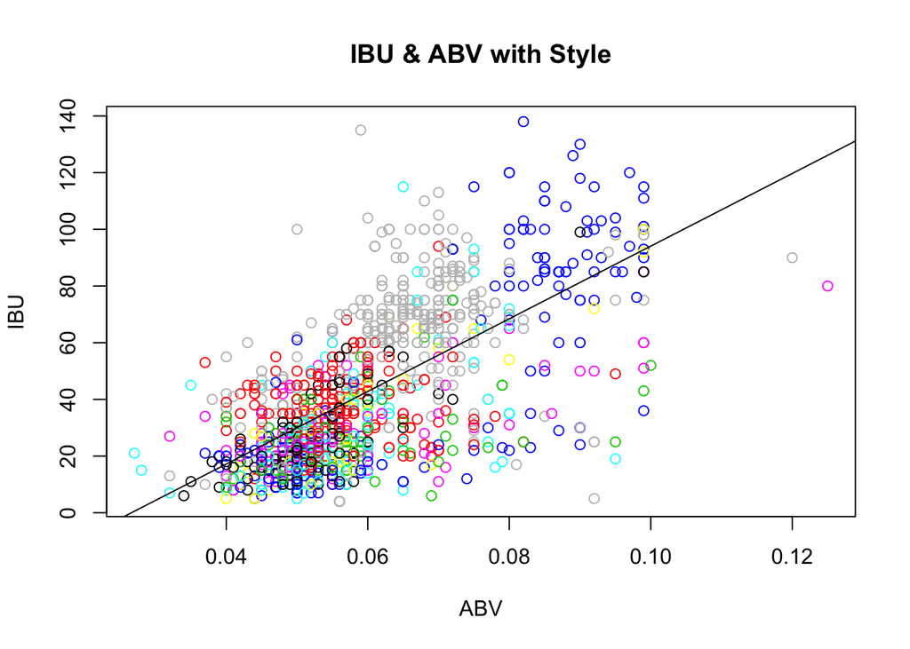

```r
plot(IBU~ABV, data=beer.merge,col = beer.merge$Style, main="IBU & ABV with Style")
abline(lm.fit)
```

```r
cor.test(beer.merge$ABV, beer.merge$IBU)
```

```
##
##  Pearson's product-moment correlation
##
## data:  beer.merge$ABV and beer.merge$IBU
## t = 33.863, df = 1403, p-value < 2.2e-16
## alternative hypothesis: true correlation is not equal to 0
## 95 percent confidence interval:
##  0.6407982 0.6984238
## sample estimates:
##       cor
## 0.6706215
```

# Completing the tale: Cause vs Correlation?

While the regression line and Pearson’s correlation statistic show a strong positive relationship between ABV and IBU, it is clear that there is a lot of variance in IBU’s across ABV. We see that some Styles of beer group together there is still variance. In fact, some beer Styles show significant variation in their IBU and ABV, suggesting that there is another factor.  
And that factor is sugar… https://learn.kegerator.com/raising-abv/ Alcohol is a byproduct of the fermentation process, which takes place when the yeast converts the sugars derived from the grain. Knowing that, you can increase the?alcohol by volume (ABV)?by increasing the size of the grain bill or increasing the amount of malt extract used.Though, this method can completely?change the recipe if all other factors remain the same, so a popular method for increasing the ABV of an existing beer recipe without bringing much change, is to simply add more sugar into the mix.

# GitHub address:

https://github.com/guvp2017/DDS_Case-Study-01.git